# Analyze_ab_test_results_notebook

## Analyze A/B Test Results

- Introduction
- Part I - Probability
- Part II - A/B Test
- Part III - Regression
- Part IIII - References

### Introduction

For this project, we will be working to understand the results of an A/B test run by an e-commerce website. The goal is to work through this notebook to help the company understand if they should implement the new page, keep the old page, or perhaps run the experiment longer to make their decision.

#### Part I - Probability

To get started, let's import our libraries.

```python
import pandas as pd
import numpy as np
import random

import matplotlib.pyplot as plt
%matplotlib inline

import statsmodels as sm
from sklearn.linear_model import LogisticRegression
from sklearn.metrics import confusion_matrix, precision_score, recall_score, accuracy_score
from statsmodels.stats.proportion import proportions_ztest
import statsmodels.api as sm
from scipy.stats import norm

#We are setting the seed to assure we get the same answers as the quizzes
random.seed(42)
```

`1.` Now, read in the `ab_data.csv` data. Store it in `df`. **Use your dataframe to answer the questions in Quiz 1 of the classroom.**

a. Read in the dataset and take a look at the top few rows here:

```python
df = pd.read_csv('ab_data.csv')
df.head()
```

|  | user_id | timestamp | group | landing_page | converted |
| --- | --- | --- | --- | --- | --- |
| 0 | 851104 | 2017-01-21 22:11:48.556739 | control | old_page | 0 |
| 1 | 804228 | 2017-01-12 08:01:45.159739 | control | old_page | 0 |
| 2 | 661590 | 2017-01-11 16:55:06.154213 | treatment | new_page | 0 |
| 3 | 853541 | 2017-01-08 18:28:03.143765 | treatment | new_page | 0 |
| 4 | 864975 | 2017-01-21 01:52:26.210827 | control | old_page | 1 |

b. Use the cell below to find the number of rows in the dataset.

```python
df.shape
```

```
(294478, 5)
```

c. The number of unique users in the dataset.

```python
df['user_id'].nunique()
```

```
290584
```

d. The proportion of users converted.

```python
df.query('converted == 1').shape[0]/df.shape[0]
```

```
0.11965919355605512
```

e. The number of times the `new_page` and `treatment` don't match.

```python
df[((df['group'] == 'treatment') == (df['landing_page'] == 'new_page')) == False].shape[0]
```

```
3893
```

f. Do any of the rows have missing values?

```python
df.isnull().sum()
```

```
user_id         0
timestamp       0
group           0
landing_page    0
converted       0
dtype: int64
```

`2.` For the rows where **treatment** does not match with **new_page** or **control** does not match with **old_page**, we cannot be sure if this row truly received the new or old page. Use **Quiz 2** in the classroom to figure out how we should handle these rows.

a. Now use the answer to the quiz to create a new dataset that meets the specifications from the quiz. Store your new dataframe in **df2**.

```python
df_new = df[((df['group'] == 'treatment') & (df['landing_page'] == 'new_page'))]
df_old = df[((df['group'] == 'control') & (df['landing_page'] == 'old_page'))]
df2 = pd.concat([df_old, df_new])
df2.head(3)
```

|  | user_id | timestamp | group | landing_page | converted |
| --- | --- | --- | --- | --- | --- |
| 0 | 851104 | 2017-01-21 22:11:48.556739 | control | old_page | 0 |
| 1 | 804228 | 2017-01-12 08:01:45.159739 | control | old_page | 0 |
| 4 | 864975 | 2017-01-21 01:52:26.210827 | control | old_page | 1 |

```python
df2.shape
```

```
(290585, 5)
```

```python
df2[((df2['group'] == 'treatment') == (df2['landing_page'] == 'new_page')) == True].shape[0]
```

```
290585
```

`3.` Use **df2** and the cells below to answer questions for **Quiz3** in the classroom.

a. How many unique **user_id**s are in **df2**?

```python
uni = df2['user_id'].nunique()
print("Unique user_ids in df2 :", uni)
```

```
Unique user_ids in df2 : 290584
```

b. There is one **user_id** repeated in **df2**. What is it?

```python
df2['user_id'].value_counts().max()
df2.user_id.value_counts().head(1)
```

```
773192    2
Name: user_id, dtype: int64
```

c. What is the row information for the repeat **user_id**?

```python
df2.loc[df['user_id'] == 773192]
```

|  | user_id | timestamp | group | landing_page | converted |
| --- | --- | --- | --- | --- | --- |
| 1899 | 773192 | 2017-01-09 05:37:58.781806 | treatment | new_page | 0 |
| 2893 | 773192 | 2017-01-14 02:55:59.590927 | treatment | new_page | 0 |

d. Remove **one** of the rows with a duplicate **user_id**, but keep your dataframe as **df2**.

```python
df2 = df2.drop_duplicates(subset='user_id');
```

```python
df2.loc[df['user_id'] == 773192]
```

|  | user_id | timestamp | group | landing_page | converted |
| --- | --- | --- | --- | --- | --- |
| 1899 | 773192 | 2017-01-09 05:37:58.781806 | treatment | new_page | 0 |

```python
# Double Check all of the correct rows were removed - this should be 0
df2[((df2['group'] == 'treatment') == (df2['landing_page'] == 'new_page')) == False].shape[0]
```

```
0
```

`4.` Use **df2** in the cells below to answer the quiz questions related to **Quiz 4** in the classroom.

a. What is the probability of an individual converting regardless of the page they receive?

```python
prob = df2['converted'].mean()
print('The probability of an individual converting regardless of the page they receive is: {}.'.format(prob))
```

```
The probability of an individual converting regardless of the page they receive is: 0.11959708724499628.
```

b. Given that an individual was in the `control` group, what is the probability they converted?

```python
prob2 = df2.query('group == "control"').converted.mean()
print('Given that an individual was in the control group, the probability they converted is:', prob2)
```

```
Given that an individual was in the control group, the probability they converted is: 0.1203863045004612
```

c. Given that an individual was in the `treatment` group, what is the probability they converted?

```python
prob3 = df2.query('group == "treatment"').converted.mean()
print('Given that an individual was in the treatment group, the probability they converted is:', prob3)
```

```
Given that an individual was in the treatment group, the probability they converted is: 0.11880806551510564
```

d. What is the probability that an individual received the new page?

```python
prob4 = len(df2[df2['landing_page'] == 'new_page']) / len(df2)
print('The probability that an individual received the new page is:', prob4)
```

```
The probability that an individual received the new page is: 0.5000619442226688
```

Before we begin our tests, we hope that the new page is better. However this needs to be proved. The propability that the new page is better, is the alternative hypothesis. In order to prove it we will follow some steps. In the parts a-d we investigated our data and came up to some calculations about the propabilities both of the control and treatment group. As we discovered:

- Given that an individual was in the control group, the probability they converted is: 0.1203863045004612
- Given that an individual was in the treatment group, the probability they converted is: 0.11880806551510564

We can see that the conversion rate is pretty similar in both situations, and we need to further investigate, considering other factors as well. The analysis needs further investigation in order to have conclusions and that will take place in the next steps.

### Part II - A/B Test

Notice that because of the time stamp associated with each event, you could technically run a hypothesis test continuously as each observation was observed.

However, then the hard question is do you stop as soon as one page is considered significantly better than another or does it need to happen consistently for a certain amount of time? How long do you run to render a decision that neither page is better than another?

These questions are the difficult parts associated with A/B tests in general.

`1.` Now, we need to make the decision just based on all the data provided. We want to assume that the old page is better unless the new page proves to be definitely better at a Type I error rate of 5%, what should your null and alternative hypotheses be?

$$H_0: p_{new} - p_{old}<= 0 $$$$H_1: p_{new} - p_{old}> 0 $$

`2.` We will assume under the null hypothesis, $p_{new}$ and $p_{old}$ both have "true" success rates equal to the **converted** success rate regardless of page - that is $p_{new}$ and $p_{old}$ are equal. Furthermore, we will assume they are equal to the **converted** rate in **ab_data.csv** regardless of the page.

- We will use a sample size for each page equal to the ones in **ab_data.csv**.
- We will perform the sampling distribution for the difference in **converted** between the two pages over 10,000 iterations of calculating an estimate from the null.

Use the cells below to provide the necessary parts of this simulation. If this doesn't make complete sense right now, don't worry - you are going to work through the problems below to complete this problem. You can use **Quiz 5** in the classroom to make sure you are on the right track.

a. What is the **conversion rate** for $p_{new}$ under the null?

```python
p_new = df2['converted'].mean()
print('The conversion rate of p new under the null is:', p_new)
```

```
The conversion rate of p new under the null is: 0.11959708724499628
```

b. What is the **conversion rate** for $p_{old}$ under the null?

```python
#calculate number of queries when landing_page is equal to old_page
p_old = df2['converted'].mean()
#print results
print('The conversion rate of p old under the null is:', p_old)
```

```
The conversion rate of p old under the null is: 0.11959708724499628
```

c. What is $n_{new}$, the number of individuals in the treatment group?

```python
n_new = (df2.landing_page == 'new_page').sum()
print('We calculate n_new as:', n_new)
```

```
We calculate n_new as: 145310
```

d. What is $n_{old}$, the number of individuals in the control group?

```python
n_old = (df2.landing_page == 'old_page').sum()
print('We calculate n_old as:', n_old)
```

```
We calculate n_old as: 145274
```

e. Simulate $n_{new}$ transactions with a conversion rate of $p_{new}$ under the null. Store these $n_{new}$ 1's and 0's in **new_page_converted**.

```python
new_page_converted = np.random.choice([0,1],n_new, p=(p_new,1-p_new))
new_page_converted
```

```
array([1, 1, 1, ..., 1, 1, 1])
```

f. Simulate $n_{old}$ transactions with a conversion rate of $p_{old}$ under the null. Store these $n_{old}$ 1's and 0's in **old_page_converted**.

```python
old_page_converted = np.random.choice([0,1],n_old, p=(p_old,1-p_old))
old_page_converted
```

```
array([1, 1, 0, ..., 1, 1, 1])
```

```python
#print('The mean is of the new page converted is:', new_page_converted.mean())
#print('The mean is of the old page converted is:',old_page_converted.mean())
```

g. Find $p_{new}$ - $p_{old}$ for your simulated values from part (e) and (f).

```python
#we calculate diff conv which is the difference between new_page and old page converted results
p_diff = new_page_converted.mean() - old_page_converted.mean()
p_diff
```

```
-6.665351338586145e-05
```

h. Create 10,000 $p_{new}$ - $p_{old}$ values using the same simulation process you used in parts (a) through (g) above. Store all 10,000 values in a NumPy array called **p_diffs**.

```python
#Bootstrapping is sampling with replacement. Using random.choice in python actually samples in this way.
new_converted_simulation = np.random.binomial(n_new, p_new,  10000)/n_new
old_converted_simulation = np.random.binomial(n_old, p_old,  10000)/n_old
p_diffs = new_converted_simulation - old_converted_simulation
```

```python
#Store all 10,000 values in a NumPy array called p_diffs.
p_diffs = np.array(p_diffs)
```

i. Plot a histogram of the **p_diffs**. Does this plot look like what you expected? Use the matching problem in the classroom to assure you fully understand what was computed here.

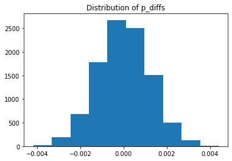

```python
plt.hist(p_diffs);
plt.title('Distribution of p_diffs');
```

j. What proportion of the **p_diffs** are greater than the actual difference observed in **ab_data.csv**?

```python
new_convert = df2.query('converted == 1 and landing_page == "new_page"').count()[0]/n_new
old_convert = df2.query('converted == 1 and landing_page == "old_page"').count()[0]/n_old
obs_diff = new_convert - old_convert
obs_diff
```

```
-0.0015782389853555567
```

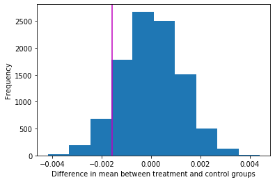

```python
#plot the obs_diffs line
plt.hist(p_diffs)

#set x y axis
plt.xlabel('Difference in mean between treatment and control groups')
plt.ylabel('Frequency')

#plot the line
plt.axvline(x= -0.0015782389853555567, c='m');
```

```python
null_vals = np.random.normal(0, p_diffs.std(), p_diffs.size)
```

```python
(null_vals > obs_diff).mean()
```

```
0.8994
```

l. We could also use a built-in to achieve similar results. Though using the built-in might be easier to code, the above portions are a walkthrough of the ideas that are critical to correctly thinking about statistical significance. Βelow, we will calculate the number of conversions for each page, as well as the number of individuals who received each page. Let `n_old` and `n_new` refer the the number of rows associated with the old page and new pages, respectively. For this analysis, we will use statsmodels, a Python package that allows users to explore data, estimate statistical models, and perform statistical tests

```python
convert_old = df2.query('group == "control"  and converted ==1').user_id.size
convert_new = df2.query('group == "treatment"  and converted ==1').user_id.size

n_old = df2.query('group == "control"').user_id.size
n_new = df2.query('group == "treatment"').user_id.size
```

```python
convert_old, convert_new, n_old, n_new
```

```
(17489, 17264, 145274, 145310)
```

m. Now use `stats.proportions_ztest` to compute your test statistic and p-value. [Here](https://docs.w3cub.com/statsmodels/generated/statsmodels.stats.proportion.proportions_ztest/) is a helpful link on using the built in.

```python
z_score, p_value = sm.stats.proportions_ztest([convert_old, convert_new], [n_old, n_new], alternative="smaller")
z_score, p_value
```

```
(1.3109241984234394, 0.9050583127590245)
```